# Did Derrick Rose Deserve the 2010-11 MVP?

Ife Obateru

## The question

In 2011, Derrick Rose became the youngest MVP in NBA history at just 22 years old, winning 113 of 121 first-place votes after leading the Chicago Bulls to the league’s best record (62-20). However, the award is still debated today, because other players, especially LeBron James, put up stronger numbers that season. In this report, I use MVP voting data and regression analysis to test whether Rose’s MVP was backed up by the stats, or whether something else drove the voters.

## The data

Data comes from Basketball-Reference: official MVP voting results (with each candidate’s stats) and team ratings for the 2005-06 through 2014-15 seasons.

```r
mvp <- read_csv("data/mvp_2011.csv")

mvp <- mvp |>
  select(-`-9999`) |>
  rename(
    pts_won = `Pts Won`,
    pts_max = `Pts Max`,
    fg_pct  = `FG%`,
    fg3_pct = `3P%`,
    ft_pct  = `FT%`,
    ws_48   = `WS/48`
  ) |>
  mutate(
    Rank    = parse_number(Rank),
    is_rose = Player == "Derrick Rose"
  )
```

## How Rose compared to other candidates

Rose ranked 4th in Win Shares and 6th in scoring among the 13 players who received MVP votes, yet he received 98% of the possible vote points.

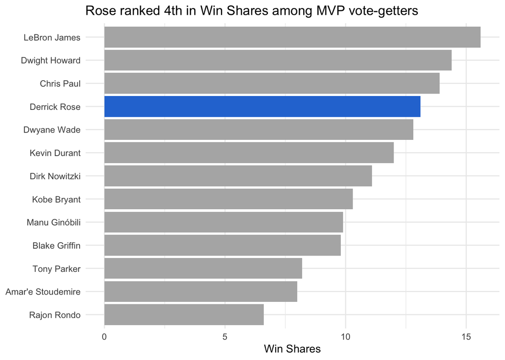

```r
ggplot(mvp, aes(x = WS, y = reorder(Player, WS), fill = is_rose)) +
  geom_col() +
  scale_fill_manual(values = c("TRUE" = "#2a78d6", "FALSE" = "grey70"), guide = "none") +
  labs(
    title = "Rose ranked 4th in Win Shares among MVP vote-getters",
    x = "Win Shares",
    y = NULL
  ) +
  theme_minimal()
```

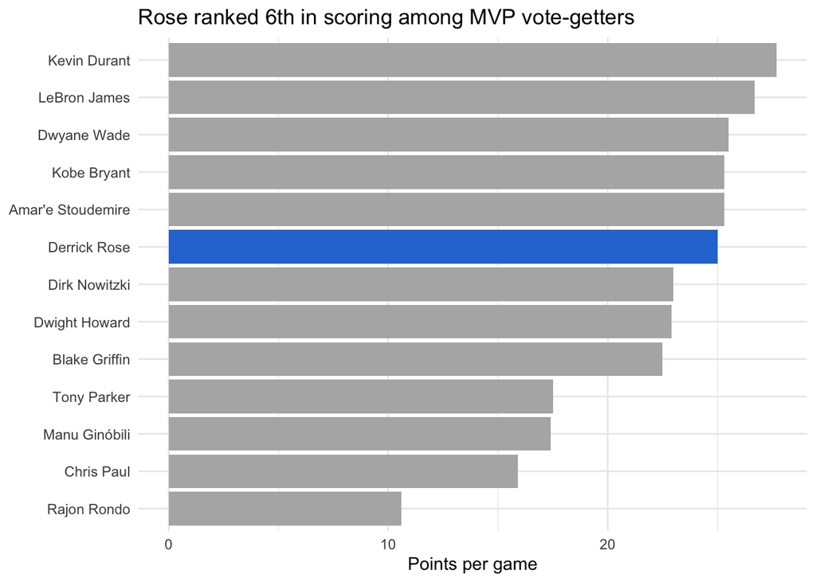

```r
ggplot(mvp, aes(x = PTS, y = reorder(Player, PTS), fill = is_rose)) +
  geom_col() +
  scale_fill_manual(values = c("TRUE" = "#2a78d6", "FALSE" = "grey70"), guide = "none") +
  labs(
    title = "Rose ranked 6th in scoring among MVP vote-getters",
    x = "Points per game",
    y = NULL
  ) +
  theme_minimal()
```

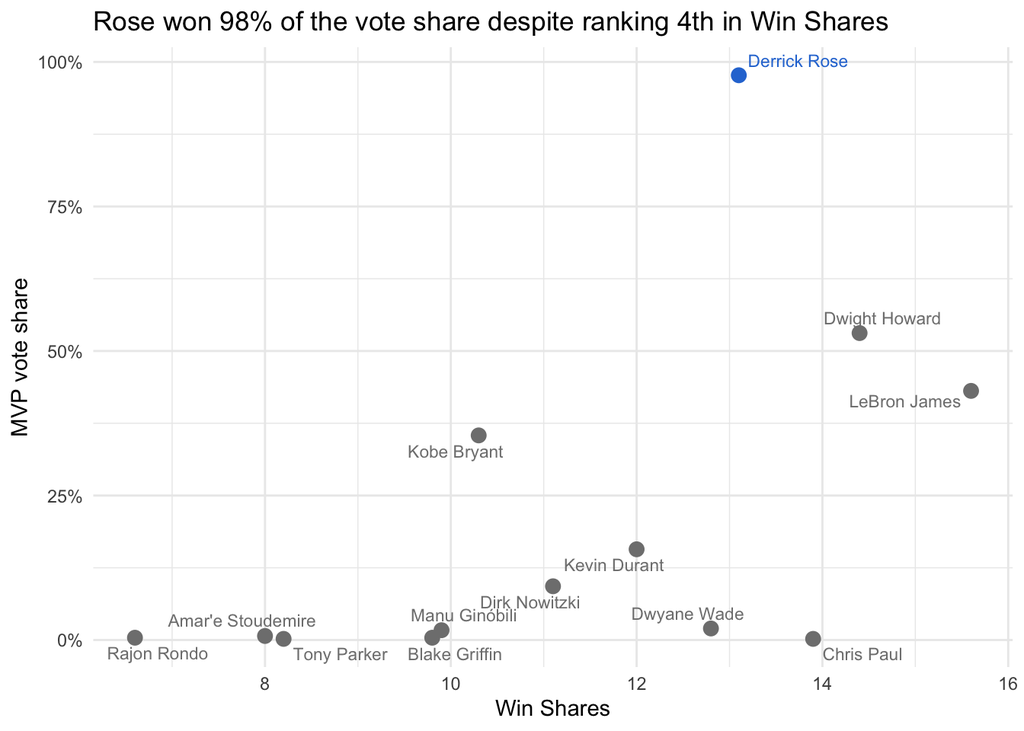

```r
ggplot(mvp, aes(x = WS, y = Share, color = is_rose)) +
  geom_point(size = 3) +
  geom_text_repel(aes(label = Player), size = 3) +
  scale_color_manual(values = c("TRUE" = "#2a78d6", "FALSE" = "grey50"), guide = "none") +
  scale_y_continuous(labels = scales::percent) +
  labs(
    title = "Rose won 98% of the vote share despite ranking 4th in Win Shares",
    x = "Win Shares",
    y = "MVP vote share"
  ) +
  theme_minimal()
```

## What do MVP voters usually reward?

To learn what voters typically reward, I trained regression models on nine other seasons of MVP voting (2006-2015, excluding 2011), then used them to predict the 2011 vote.

```r
files <- list.files("data", pattern = "^mvp_\\d{4}\\.csv$", full.names = TRUE)

all_mvp <- read_csv(files, id = "file") |>
  select(-`-9999`) |>
  rename(
    pts_won = `Pts Won`,
    pts_max = `Pts Max`,
    fg_pct  = `FG%`,
    fg3_pct = `3P%`,
    ft_pct  = `FT%`,
    ws_48   = `WS/48`
  ) |>
  mutate(
    Rank   = parse_number(Rank),
    season = parse_number(file)
  )

team_files <- list.files("data", pattern = "^teams_\\d{4}\\.csv$", full.names = TRUE)

teams <- read_csv(team_files, id = "file") |>
  mutate(
    season = parse_number(file),
    Team   = str_remove(Team, "\\*")
  ) |>
  select(season, Team, W, L, MOV)

abbrevs <- read_csv("data/team_abbrevs.csv")

all_mvp <- all_mvp |>
  left_join(abbrevs, by = "Tm") |>
  left_join(teams, by = c("season", "Team"))

# Drop players traded mid-season (team = "TOT"), since they have no single team record
all_mvp <- all_mvp |>
  filter(!is.na(W)) |>
  mutate(win_pct = W / (W + L))

# How many teammates also received MVP votes that season?
all_mvp <- all_mvp |>
  group_by(season, Tm) |>
  mutate(teammates_voted = n() - 1) |>
  ungroup()
```

```r
train <- all_mvp |> filter(season != 2011)
test  <- all_mvp |> filter(season == 2011)

model1 <- lm(Share ~ WS, data = train)                              # Win Shares only
model2 <- lm(Share ~ WS + Age, data = train)                        # + age (not significant)
model3 <- lm(Share ~ WS + W, data = train)                          # + team wins
model4 <- lm(Share ~ WS + win_pct, data = train)                    # + team win %
model5 <- lm(Share ~ WS + win_pct + teammates_voted, data = train)  # + teammates who got votes

rose <- test |> filter(Player == "Derrick Rose")

model_comparison <- tibble(
  model = c("1: WS", "2: WS + age", "3: WS + team wins",
            "4: WS + win %", "5: WS + win % + teammates"),
  adj_r2 = c(summary(model1)$adj.r.squared,
             summary(model2)$adj.r.squared,
             summary(model3)$adj.r.squared,
             summary(model4)$adj.r.squared,
             summary(model5)$adj.r.squared),
  rose_predicted = c(predict(model1, rose),
                     predict(model2, rose),
                     predict(model3, rose),
                     predict(model4, rose),
                     predict(model5, rose))
) |>
  mutate(rose_gap = rose$Share - rose_predicted)

knitr::kable(model_comparison, digits = 3)
```

| model | adj_r2 | rose_predicted | rose_gap |
| --- | --- | --- | --- |
| 1: WS | 0.439 | 0.285 | 0.692 |
| 2: WS + age | 0.448 | 0.241 | 0.736 |
| 3: WS + team wins | 0.445 | 0.317 | 0.660 |
| 4: WS + win % | 0.477 | 0.349 | 0.628 |
| 5: WS + win % + teammates | 0.483 | 0.388 | 0.589 |

```r
test |>
  mutate(predicted = predict(model4, newdata = test)) |>
  select(Player, WS, win_pct, Share, predicted) |>
  arrange(desc(predicted)) |>
  knitr::kable(digits = 3)
```

| Player | WS | win_pct | Share | predicted |
| --- | --- | --- | --- | --- |
| LeBron James | 15.6 | 0.707 | 0.431 | 0.445 |
| Derrick Rose | 13.1 | 0.756 | 0.977 | 0.349 |
| Dwight Howard | 14.4 | 0.634 | 0.531 | 0.335 |
| Dwyane Wade | 12.8 | 0.707 | 0.020 | 0.301 |
| Chris Paul | 13.9 | 0.561 | 0.002 | 0.262 |
| Kevin Durant | 12.0 | 0.671 | 0.157 | 0.236 |
| Dirk Nowitzki | 11.1 | 0.695 | 0.093 | 0.206 |
| Manu Ginóbili | 9.9 | 0.744 | 0.017 | 0.177 |
| Kobe Bryant | 10.3 | 0.695 | 0.354 | 0.165 |
| Tony Parker | 8.2 | 0.744 | 0.002 | 0.090 |
| Rajon Rondo | 6.6 | 0.683 | 0.004 | -0.032 |
| Blake Griffin | 9.8 | 0.390 | 0.004 | -0.060 |
| Amar’e Stoudemire | 8.0 | 0.512 | 0.007 | -0.072 |

Win Shares was the strongest predictor of vote share, and team win percentage also mattered; age did not. Even after accounting for Win Shares, team win percentage, and teammates splitting votes, the model predicted Rose would receive 39% of the vote share. Instead, he got 98%. Something beyond the stats, most likely the story of a 22-year-old leading his hometown team to the league’s best record, drove voters in 2011.

## Comparing Rose to other MVP winners

```r
all_mvp |>
  filter(Rank == 1) |>
  select(season, Player, WS, ws_48, win_pct) |>
  arrange(WS) |>
  knitr::kable(digits = 3)
```

| season | Player | WS | ws_48 | win_pct |
| --- | --- | --- | --- | --- |
| 2006 | Steve Nash | 12.4 | 0.212 | 0.659 |
| 2011 | Derrick Rose | 13.1 | 0.208 | 0.756 |
| 2008 | Kobe Bryant | 13.8 | 0.208 | 0.695 |
| 2012 | LeBron James | 14.5 | 0.298 | 0.697 |
| 2015 | Stephen Curry | 15.7 | 0.288 | 0.817 |
| 2007 | Dirk Nowitzki | 16.3 | 0.278 | 0.817 |
| 2010 | LeBron James | 18.5 | 0.299 | 0.744 |
| 2014 | Kevin Durant | 19.2 | 0.295 | 0.720 |
| 2013 | LeBron James | 19.3 | 0.322 | 0.805 |
| 2009 | LeBron James | 20.3 | 0.318 | 0.805 |

Rose’s 13.1 Win Shares is the second-lowest among the ten MVP winners from 2006 to 2015. LeBron’s 15.6 would have been close to a typical MVP total.